# TP2: Analyse de Données. Auteurs: Dellouve Théo et Gazzo Sandro.

# Exo1

```r
tit<-read.table("titanic.csv", sep=",",header=TRUE) #on charge la table du titanic
```

```r
tit$Age<-factor(tit$Age)
levels(tit$Age)<-c("enfant","adulte") #on remplace 1 et 0 par adulte et enfant


tit$Classe<-factor(tit$Classe)
levels(tit$Classe)<-c("equipage","1ere classe","2eme classe","3eme classe")

tit$Sexe<-factor(tit$Sexe)
levels(tit$Sexe)<-c("femme","homme")

tit$Survie<-factor(tit$Survie)
levels(tit$Survie)<-c("décédé","survivant")
```

## Tableaux des effectifs croisés et des effectifs attendus

```r
table1<-table(tit$Classe,tit$Survie) #tabeau effectif croisé
table1<-addmargins(table1) # rajoute les totaux
table1
```

```
##
##               décédé survivant  Sum
##   equipage       673       212  885
##   1ere classe    122       203  325
##   2eme classe    167       118  285
##   3eme classe    528       178  706
##   Sum           1490       711 2201
```

```r
table2<-table1
#on fait un produit en croix
#table2 est une matrice
table2[1]<-table2[5]*table2[11]/table2[15]
table2[2]<-table2[5]*table2[12]/table2[15]
table2[3]<-table2[5]*table2[13]/table2[15]
table2[4]<-table2[5]*table2[14]/table2[15]

table2[6]<-table2[10]*table2[11]/table2[15]
table2[7]<-table2[10]*table2[12]/table2[15]
table2[8]<-table2[10]*table2[13]/table2[15]
table2[9]<-table2[10]*table2[14]/table2[15]

table2 #VALEURS ATTENDUES
```

```
##
##                   décédé  survivant        Sum
##   equipage     599.11404  285.88596  885.00000
##   1ere classe  220.01363  104.98637  325.00000
##   2eme classe  192.93503   92.06497  285.00000
##   3eme classe  477.93730  228.06270  706.00000
##   Sum         1490.00000  711.00000 2201.00000
```

```r
#on refait la même chose mais pour les enfants et adultes cette fois
table3<-table(tit$Age,tit$Survie) #tabeau effectif croisé
table3<-addmargins(table3) # rajoute les totaux
table3
```

```
##
##          décédé survivant  Sum
##   enfant     52        57  109
##   adulte   1438       654 2092
##   Sum      1490       711 2201
```

```r
table4<-table3
#toujours un produit en croix
table4[1]<-table4[3]*table4[7]/table4[9]
table4[2]<-table4[3]*table4[8]/table4[9]

table4[4]<-table4[6]*table4[7]/table4[9]
table4[5]<-table4[6]*table4[8]/table4[9]

table4 #VALEURS ATTENDUES
```

```
##
##              décédé  survivant        Sum
##   enfant   73.78919   35.21081  109.00000
##   adulte 1416.21081  675.78919 2092.00000
##   Sum    1490.00000  711.00000 2201.00000
```

## Test

On va faire le test du Chi-deux d’indépendance suivant: $\mathcal{H}_0: \textit{la variable classe et la variable survie sont "indépendantes"}$ contre $\mathcal{H}_1: \textit{la variable classe et la variable survie sont "dépendantes"}$.

```r
VariableXasfactor<-as.factor(table1[1:4]) # colonne decede
VariableYasfactor<-as.factor(table1[6:9]) # colonne survivant
chisq.test(VariableXasfactor,VariableYasfactor)
```

```
##
##  Pearson's Chi-squared test
##
## data:  VariableXasfactor and VariableYasfactor
## X-squared = 12, df = 9, p-value = 0.2133
```

Toujours par un test du Chi-deux d’indépendance: $\mathcal{H}_0: \textit{la variable sexe et la variable survie sont "indépendantes"}$ contre $\mathcal{H}_1: \textit{la variable sexe et la variable survie sont "dépendantes"}$.

```r
chisq.test(tit$Sexe,tit$Survie)
```

```
##
##  Pearson's Chi-squared test with Yates' continuity correction
##
## data:  tit$Sexe and tit$Survie
## X-squared = 454.5, df = 1, p-value < 2.2e-16
```

Enfin, on va faire la même chose avec la variable âge: $\mathcal{H}_0: \textit{la variable âge et la variable survie sont "indépendantes"}$ contre $\mathcal{H}_1: \textit{la variable âge et la variable survie sont "dépendantes"}$.

```r
chisq.test(tit$Age,tit$Survie)
```

```
##
##  Pearson's Chi-squared test with Yates' continuity correction
##
## data:  tit$Age and tit$Survie
## X-squared = 20.005, df = 1, p-value = 7.725e-06
```

## AFC pour les variables classe et survie

```r
library("FactoMineR")
library("factoextra")
ca<-CA(table1) #AFC
```

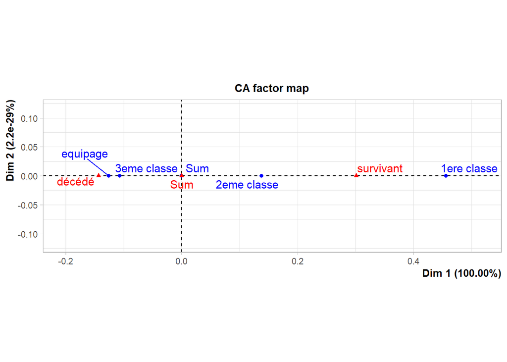

```r
ca
```

```
## **Results of the Correspondence Analysis (CA)**
## The row variable has  5  categories; the column variable has 3 categories
## The chi square of independence between the two variables is equal to 190.4011 (p-value =  6.705773e-37 ).
## *The results are available in the following objects:
##
##    name              description
## 1  "$eig"            "eigenvalues"
## 2  "$col"            "results for the columns"
## 3  "$col$coord"      "coord. for the columns"
## 4  "$col$cos2"       "cos2 for the columns"
## 5  "$col$contrib"    "contributions of the columns"
## 6  "$row"            "results for the rows"
## 7  "$row$coord"      "coord. for the rows"
## 8  "$row$cos2"       "cos2 for the rows"
## 9  "$row$contrib"    "contributions of the rows"
## 10 "$call"           "summary called parameters"
## 11 "$call$marge.col" "weights of the columns"
## 12 "$call$marge.row" "weights of the rows"
```

```r
ca$eig
```

```
##         eigenvalue percentage of variance cumulative percentage of variance
## dim 1 2.162666e-02           1.000000e+02                               100
## dim 2 4.743838e-33           2.193514e-29                               100
```

```r
ca$col
```

```
## $coord
##                Dim 1        Dim 2
## décédé    -0.1436651 6.708801e-33
## survivant  0.3010704 6.708801e-33
## Sum        0.0000000 0.000000e+00
##
## $contrib
##             Dim 1        Dim 2
## décédé    32.3035 3.211413e-31
## survivant 67.6965 1.532426e-31
## Sum        0.0000 0.000000e+00
##
## $cos2
##           Dim 1        Dim 2
## décédé        1 2.180655e-63
## survivant     1 4.965394e-64
## Sum         NaN          NaN
##
## $inertia
## [1] 0.006986167 0.014640491 0.000000000
```

```r
ca$row
```

```
## $coord
##                  Dim 1         Dim 2
## equipage    -0.1262396 -1.820627e-33
## 1ere classe  0.4560162  1.827826e-33
## 2eme classe  0.1376002  8.024288e-33
## 3eme classe -0.1072227  1.042255e-32
## Sum          0.0000000  0.000000e+00
##
## $contrib
##                 Dim 1        Dim 2
## equipage    14.814784 1.404770e-32
## 1ere classe 70.991171 5.199637e-33
## 2eme classe  5.668177 8.787755e-32
## 3eme classe  8.525867 3.672590e-31
## Sum          0.000000 0.000000e+00
##
## $cos2
##             Dim 1        Dim 2
## equipage        1 2.079938e-64
## 1ere classe     1 1.606605e-65
## 2eme classe     1 3.400753e-63
## 3eme classe     1 9.448748e-63
## Sum           NaN          NaN
##
## $inertia
## [1] 0.003203943 0.015353018 0.001225837 0.001843860 0.000000000
```

On ne peut choisir qu’un axe car une seule valeur propre, qui exprime la survie de l’individu. On constate qu’il y a une attirance entre la première classe/la deuxième classe et survivant. De même, il y a une attirance entre la troisième classe/l’équipage et décés.

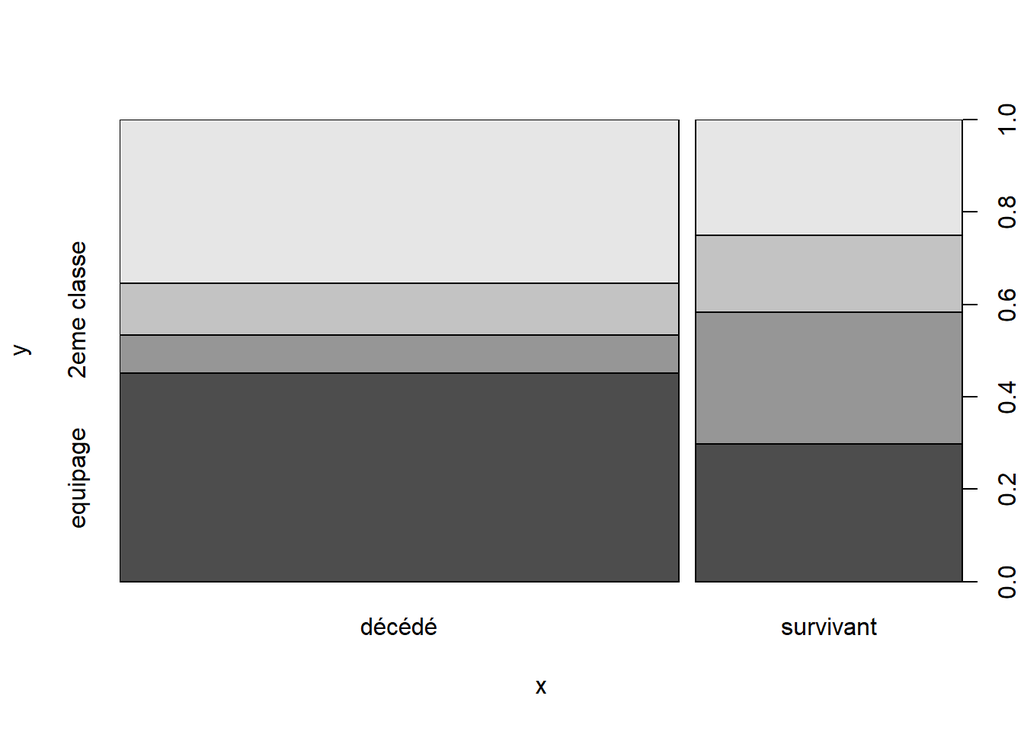

```r
plot(tit$Survie, tit$Classe)
```

# Exo2

```r
bebe<-read.table("bebe.txt", sep=" ",header=TRUE) #on stock la table
summary(bebe)
```

```
##       bwt          gestation       parity             age
##  Min.   :1.570   Min.   :148.0   Mode :logical   Min.   :15.00
##  1st Qu.:3.105   1st Qu.:272.0   FALSE:921       1st Qu.:23.00
##  Median :3.430   Median :280.0   TRUE :315       Median :26.00
##  Mean   :3.416   Mean   :279.3                   Mean   :27.37
##  3rd Qu.:3.740   3rd Qu.:288.0                   3rd Qu.:31.00
##  Max.   :5.030   Max.   :353.0                   Max.   :99.00
##                  NA's   :13
##      height          weight         smoke            tension
##  Min.   :132.5   Min.   : 39.41   Mode :logical   Min.   : 9.20
##  1st Qu.:155.0   1st Qu.: 52.09   FALSE:742       1st Qu.:12.50
##  Median :160.0   Median : 57.08   TRUE :484       Median :13.70
##  Mean   :160.1   Mean   : 85.67   NA's :10        Mean   :14.41
##  3rd Qu.:165.0   3rd Qu.: 63.42                   3rd Qu.:16.20
##  Max.   :180.0   Max.   :999.00                   Max.   :23.70
##  NA's   :22
```

## Histogramme

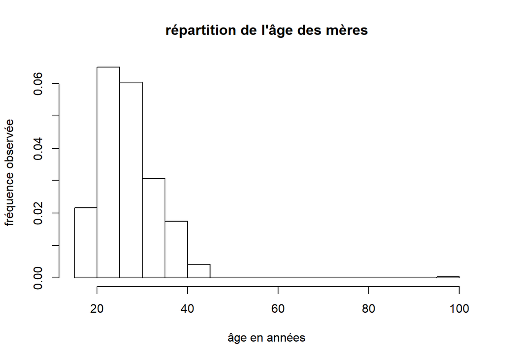

```r
hist(bebe$age, freq=F,main="répartition de l'âge des mères", xlab="âge en années",ylab="fréquence observée")
```

Des femmes auraient eu un enfant à 99 ans. C’est une information erronée.

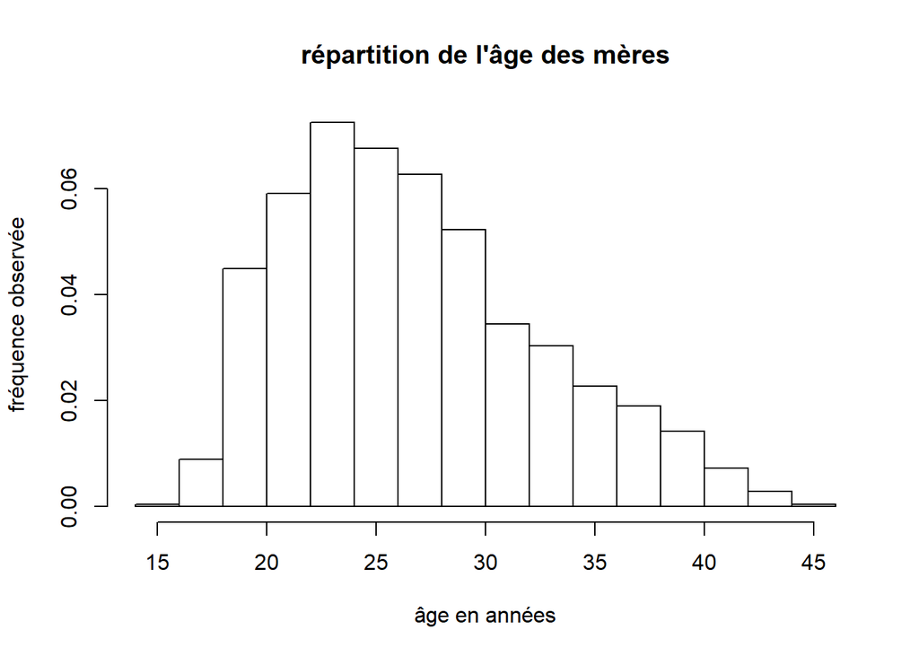

```r
bebe2<-bebe[bebe$age!=99,] # on enleve les lignes avec age de 99 ans

hist(bebe2$age, freq=F,main="répartition de l'âge des mères", xlab="âge en années",ylab="fréquence observée")
```

```r
#il n'y a plus de valeurs étranges
```

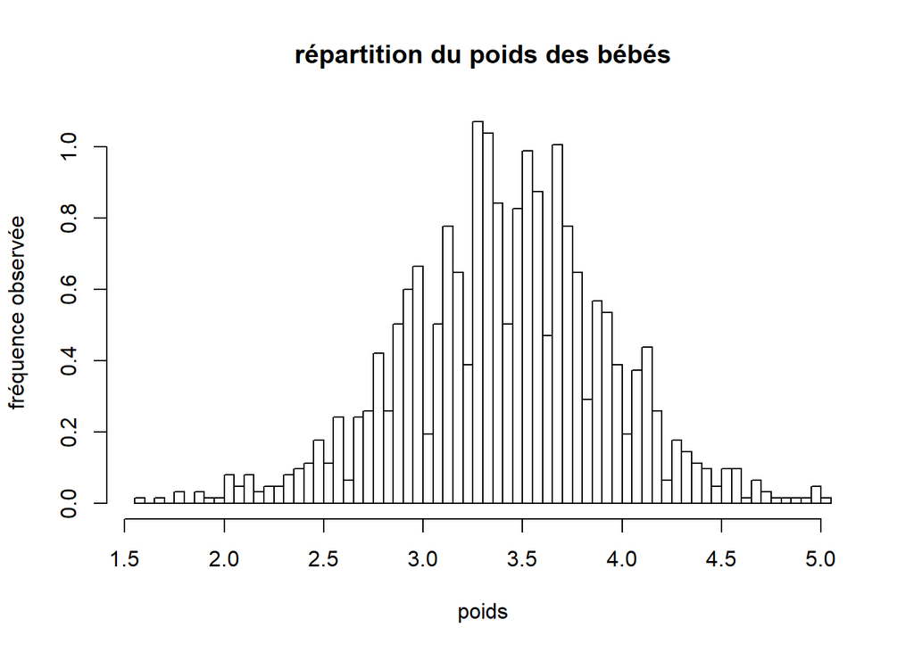

```r
hist(bebe2$bwt, freq=F, breaks=70,main="répartition du poids des bébés", xlab="poids",ylab="fréquence observée")
```

## Estimation de densités

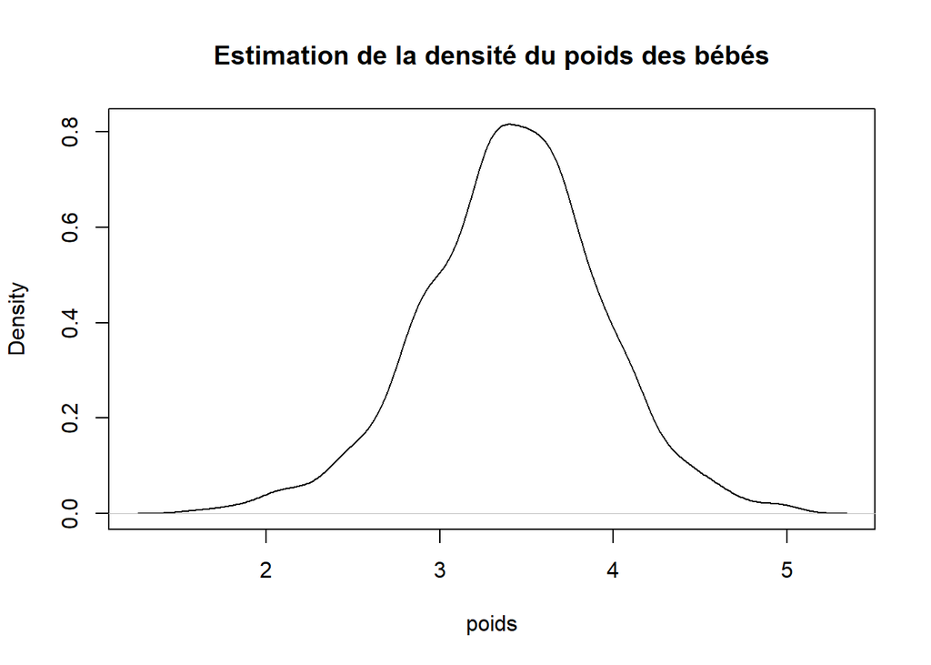

```r
plot(density(bebe2$bwt), main = "Estimation de la densité du poids des bébés", xlab="poids")
```

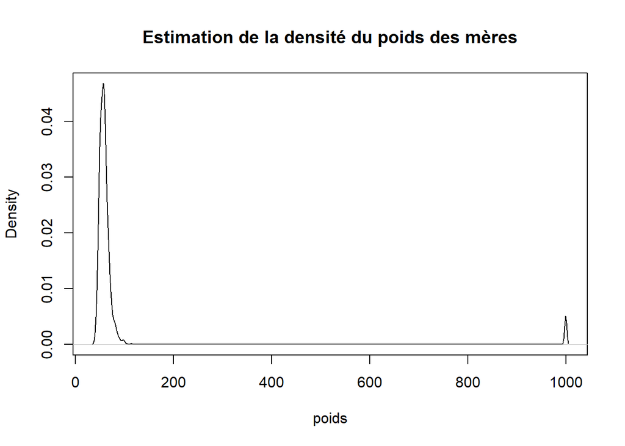

```r
plot(density(bebe2$weight), main = "Estimation de la densité du poids des mères", xlab="poids")
```

Selon le graphique, il y aurait des femmes pesant une tonne. Ce sont des valeurs erronées.

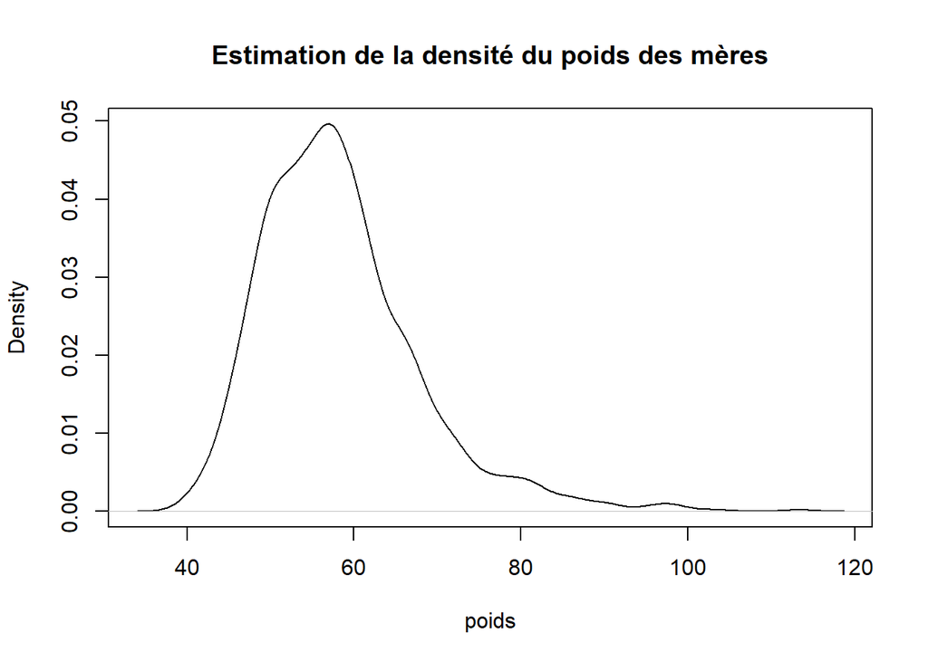

```r
bebe3<-bebe2[bebe2$weight!=999,] #on enlève les valeurs erronées

#on vérifie si cela est bien enlevé

plot(density(bebe3$weight), main = "Estimation de la densité du poids des mères", xlab="poids")
```

On a bien enlevé les valeurs erronées.

## Etude du poids de la mère et de l’enfant

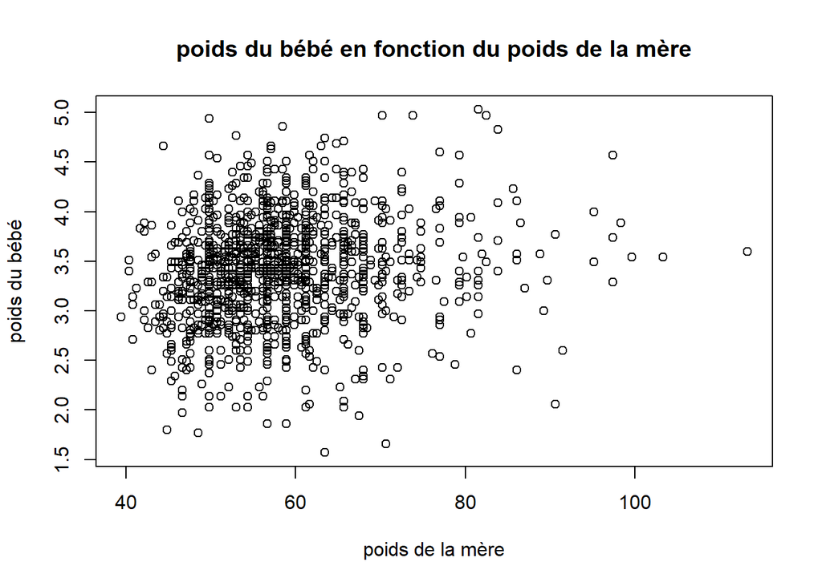

```r
plot(bebe3$weight,bebe3$bwt, main="poids du bébé en fonction du poids de la mère", xlab="poids de la mère", ylab="poids du bébé")
```

```r
#création des nouvelles variables qualitatives

# d'abord 1, puis 2 puis 3...
weightClass<-cut(bebe3$weight,c(0,50,60,70,120),label=F)


bwtClass<-cut(bebe3$bwt,c(0,3,3.5,4,6),label=F)
```

```r
chisq.test(weightClass,bwtClass) #test d'independance ?
```

```
##
##  Pearson's Chi-squared test
##
## data:  weightClass and bwtClass
## X-squared = 37.257, df = 9, p-value = 2.368e-05
```

```r
table_bebe<-table(weightClass,bwtClass)
ca<-CA(table_bebe)
```

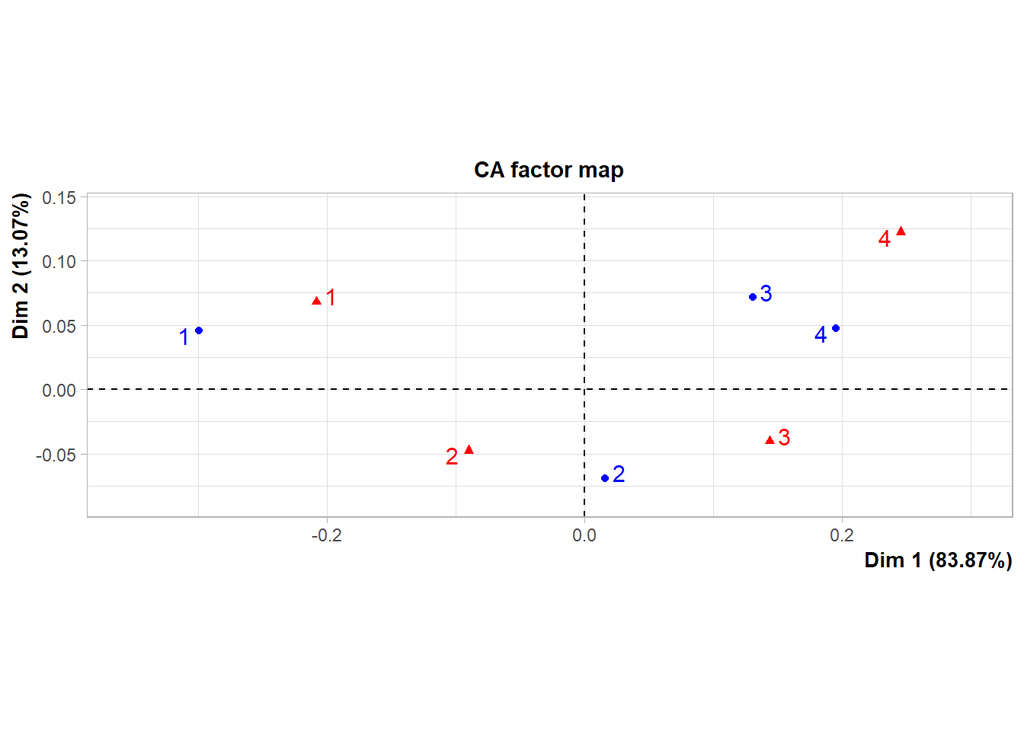

```r
# #qualite des axes > par(mfrow=c(1,2))
# barplot(ca$eig[,2], main= "inertie")
# barplot(ca$eig[,3], main="inertie cummulee")
# # observons que les v.p. sont infererieures `a 1.
# fviz_ca_row(ca, col.row = "cos2",  gradient.cols = c("#00AFBB", "#E7B800", "#FC4E07"),  repel = TRUE)
# fviz_ca_col(ca, col.col = "contrib",  gradient.cols = c("#00AFBB", "#E7B800", "#FC4E07"))
# fviz_ca_biplot(ca,col.row= "cos2",col.col="cos2",  repel = TRUE)
```

On constate qu’il y a attirance entre les premières classes entre elles, les deuxièmes classes entre elles, les troisièmes classes entre elles et les quatrièmes classes entre elles.

Ainsi une mère ayant un poids plus grand aura plus de chance d’avoir un bébé avec un poids plus grand et inversement. Donc plus un des deux individus aura un poids plus grand, plus le deuxième individu aura un poids plus grand. De même, plus un des deux individus aura un poids plus petit, plus le deuxième aura un poids plus petit.